# An end to end workflow for differential gene expression using Affymetrix microarrays

https://www.bioconductor.org/packages/devel/workflows/vignettes/maEndToEnd/inst/doc/MA-Workflow.html Paper studying the differences in gene expression in inflamed and non-inflamed tissue 14 patients suffering from Ulcerative colitis (UC) and 15 patients with Crohn’s disease (CD) were tested. 58 arrays in total. Differential expression (DE)

```r
#if (!require("BiocManager"))
    #install.packages("BiocManager") #Nativa
#BiocManager::install("maEndToEnd", version = "devel")
library(maEndToEnd)
#?maEndToEnd
#install.packages("devtools")
library(devtools)
#devtools::install_github("r-lib/remotes", force = TRUE)
library(remotes)
#packageVersion("remotes") # has to be 1.1.1.9000 or later

#remotes::install_github("b-klaus/maEndToEnd", ref="master") #No nativa
```

```r
# Estan instaladas
#BiocManager::install("maEndToEnd", version = "devel")
#install.packages("devtools")
#suppressPackageStartupMessages({library("maEndToEnd")})
#General Bioconductor packages

#BiocManager::install("Biobase")
     library(Biobase)
      #?Biobase

#BiocManager::install("oligoClasses")
     library(oligoClasses)
     #?oligoClasses
#Annotation and data import packages
   #install.packages("ArrayExpress")
#BiocManager::install("ArrayExpress")

    #library(ArrayExpress)
    #?ArrayExpress
   #BiocManager::install("pd.hugene.1.0.st.v1")
    library(pd.hugene.1.0.st.v1)
    #?pd.hugene.1.0.st.v1
#   install.packages("hugene10sttranscriptcluster.db")
    library(hugene10sttranscriptcluster.db)
    #?hugene10sttranscriptcluster.db

#Quality control and pre-processing packages
   #BiocManager::install("oligo")
    library(oligo)
    #?oligo
    #install.packages("arrayQualityMetrics")
    library(arrayQualityMetrics)
    #?arrayQualityMetrics

#Analysis and statistics packages
    #BiocManager::install("limma")
    library(limma)
    #?limma
#   install.packages("topGO")
    library(topGO)
   #?topGo
#    install.packages("ReactomePA")
    library(ReactomePA)
    #?ReactomePA
#   install.packages("clusterProfiler")
    library(clusterProfiler)
    #?clusterProfiler

#Plotting and color options packages
    #install.packages("gplots")
    library(gplots)
    #?gplots #No tiene documentacion
   #install.packages("ggplot2")
    library(ggplot2)
    #?ggplot2
    #install.packages("geneplotter") ##No estoy seguro de si instalo
    library(geneplotter)
    #?geneplotter
#   install.packages("RColorBrewer")
    library(RColorBrewer)
    #?RColorBrewer
#   install.packages("pheatmap")
    library(pheatmap)
    #?pheatmap

#Formatting/documentation packages
   #install.packages("rmarkdown") ##Fue agregado
    library(rmarkdown)
    #?rmarkdown
   #BiocManager::install("BiocStyle") ## No lo encuentra en R
   library(BiocStyle)
   #install.packages("dplyr") ##Trae errores consecutivos pero lo instalo
    library(dplyr)
   #?dplyr
    #install.packages("tidyr")
    library(tidyr)
    #?tidyr

#Helpers:
#    install.packages("stringr")
    library(stringr) #Los string son textos
   #?stringr
#    install.packages("matrixStats")
    library(matrixStats)
   #?matrixStats
    #install.packages("genefilter")
    library(genefilter)
   #?genefilter
#    install.packages("openxlsx")
    library(openxlsx)
   #openxlsx
```

These files are produced by the array scanner software and contain the measured probe intensities. Accession code E-MTAB-2967.

```r
raw_data_dir = tempdir()  #tempdir:

if (!dir.exists(raw_data_dir)) {
    dir.create(raw_data_dir)
}
```

```r
anno_AE = getAE("E-MTAB-2967", path = raw_data_dir, type = "raw")
```

```
## Copying raw data files
```

```
## Unpacking data files
```

The MAGE-TAB format specifies up to five different types of files:

- Investigation Description Format (IDF)
- Array Design Format (ADF)
- Sample and Data Relationship Format (SDRF)
- Raw data files
- Processed data files

```r
sdrf_location <- file.path(raw_data_dir, "E-MTAB-2967.sdrf.txt") #Path from temp
SDRF <- read.delim(sdrf_location) # We import the SDRF file with the read.delim function from the raw data folder in order to obtain the sample annotation.

rownames(SDRF) <- SDRF$Array.Data.File #The sample names are given in the column Array.Data.File of the SDRF data table and will be used as rownames for the SDRF file.
SDRF <- AnnotatedDataFrame(SDRF)

raw_data <- oligo::read.celfiles(filenames = file.path(raw_data_dir,
                                                SDRF$Array.Data.File),
                                    verbose = FALSE, phenoData = SDRF)#We use the function read.celfiles from the oligo package (4) to import the files
```

[output not shown]

```r
stopifnot(validObject(raw_data))
```

We now have a first look on the raw data.

```r
#The pData function of the Biobase package directly accesses the phenoData in the ExpressionSet raw_data.
head(Biobase::pData(raw_data))
```

|  | Source.Name | Characteristics.individual. | Characteristics.organism. | Characteristics.disease. | Characteristics.organism.part. | Characteristics.phenotype. | Material.Type | Protocol.REF | Protocol.REF.1 | Extract.Name | Protocol.REF.2 | Labeled.Extract.Name | Label | Protocol.REF.3 | Assay.Name | Technology.Type | Array.Design.REF | Term.Source.REF | Protocol.REF.4 | Array.Data.File | Comment..ArrayExpress.FTP.file. | Factor.Value.disease. | Factor.Value.phenotype. |
| --- | --- | --- | --- | --- | --- | --- | --- | --- | --- | --- | --- | --- | --- | --- | --- | --- | --- | --- | --- | --- | --- | --- | --- |
| 164_I_.CEL | 164_I | 164 | Homo sapiens | Crohn's disease | colon | non-inflamed colonic mucosa | organism part | P-MTAB-41361 | P-MTAB-41363 | 164_I | P-MTAB-41364 | 164_I:Biotin | biotin | P-MTAB-41366 | 164_I_ | array assay | A-AFFY-141 | ArrayExpress | P-MTAB-41367 | 164_I_.CEL | ftp://ftp.ebi.ac.uk/pub/databases/microarray/data/experiment/MTAB/E-MTAB-2967/E-MTAB-2967.raw.1.zip | Crohn's disease | non-inflamed colonic mucosa |
| 164_II.CEL | 164_II | 164 | Homo sapiens | Crohn's disease | colon | inflamed colonic mucosa | organism part | P-MTAB-41361 | P-MTAB-41363 | 164_II | P-MTAB-41364 | 164_II:Biotin | biotin | P-MTAB-41366 | 164_II | array assay | A-AFFY-141 | ArrayExpress | P-MTAB-41367 | 164_II.CEL | ftp://ftp.ebi.ac.uk/pub/databases/microarray/data/experiment/MTAB/E-MTAB-2967/E-MTAB-2967.raw.1.zip | Crohn's disease | inflamed colonic mucosa |
| 183_I.CEL | 183_I | 183 | Homo sapiens | Crohn's disease | colon | non-inflamed colonic mucosa | organism part | P-MTAB-41361 | P-MTAB-41363 | 183_I | P-MTAB-41364 | 183_I:Biotin | biotin | P-MTAB-41366 | 183_I | array assay | A-AFFY-141 | ArrayExpress | P-MTAB-41367 | 183_I.CEL | ftp://ftp.ebi.ac.uk/pub/databases/microarray/data/experiment/MTAB/E-MTAB-2967/E-MTAB-2967.raw.1.zip | Crohn's disease | non-inflamed colonic mucosa |
| 183_II.CEL | 183_II | 183 | Homo sapiens | Crohn's disease | colon | inflamed colonic mucosa | organism part | P-MTAB-41361 | P-MTAB-41363 | 183_II | P-MTAB-41364 | 183_II:Biotin | biotin | P-MTAB-41366 | 183_II | array assay | A-AFFY-141 | ArrayExpress | P-MTAB-41367 | 183_II.CEL | ftp://ftp.ebi.ac.uk/pub/databases/microarray/data/experiment/MTAB/E-MTAB-2967/E-MTAB-2967.raw.1.zip | Crohn's disease | inflamed colonic mucosa |
| 2114_I.CEL | 2114_I | 2114 | Homo sapiens | Crohn's disease | colon | non-inflamed colonic mucosa | organism part | P-MTAB-41361 | P-MTAB-41363 | 2114_I | P-MTAB-41364 | 2114_I:Biotin | biotin | P-MTAB-41366 | 2114_I | array assay | A-AFFY-141 | ArrayExpress | P-MTAB-41367 | 2114_I.CEL | ftp://ftp.ebi.ac.uk/pub/databases/microarray/data/experiment/MTAB/E-MTAB-2967/E-MTAB-2967.raw.1.zip | Crohn's disease | non-inflamed colonic mucosa |
| 2114_II.CEL | 2114_II | 2114 | Homo sapiens | Crohn's disease | colon | inflamed colonic mucosa | organism part | P-MTAB-41361 | P-MTAB-41363 | 2114_II | P-MTAB-41364 | 2114_II:Biotin | biotin | P-MTAB-41366 | 2114_II | array assay | A-AFFY-141 | ArrayExpress | P-MTAB-41367 | 2114_II.CEL | ftp://ftp.ebi.ac.uk/pub/databases/microarray/data/experiment/MTAB/E-MTAB-2967/E-MTAB-2967.raw.1.zip | Crohn's disease | inflamed colonic mucosa |

The columns of interest for us are the following:

- identifiers of the individuals, i.e. columns “Source.Name”, “Characteristics.individual.”
- disease of the individual, i.e. “Factor.Value.disease.”
- mucosa type, i.e. “Factor.Value.phenotype.”

```r
#We now subselect the corresponding columns:

Biobase::pData(raw_data) <- Biobase::pData(raw_data)[, c("Source.Name",
                                     "Characteristics.individual.",
                                     "Factor.Value.disease.",
                                     "Factor.Value.phenotype.")]
```

Quality control of the raw data

```r
#The expression intensity values are in the assayData sub-object “exprs” and can be accessed by the exprs(raw_data) function
Biobase::exprs(raw_data)[1:5, 1:5]
```

```
##   164_I_.CEL 164_II.CEL 183_I.CEL 183_II.CEL 2114_I.CEL
## 1       4496       5310      4492       4511       2872
## 2        181        280       137        101         91
## 3       4556       5104      4379       4608       2972
## 4        167        217        99         79         82
## 5         89        110        69         58         47
```

```r
# Rows: the single DNA locations on the chip.
# columns: samples of inflamed and non-inflamed tissue of every patient, respectively.
```

We then perform a principal component analysis (PCA) and plot it (Figure 2). Every point in the plot represents one sample, with the colour indicating the mucosa type (inflamed vs non-inflamed) and the shape indicating the disease (UC or CD).

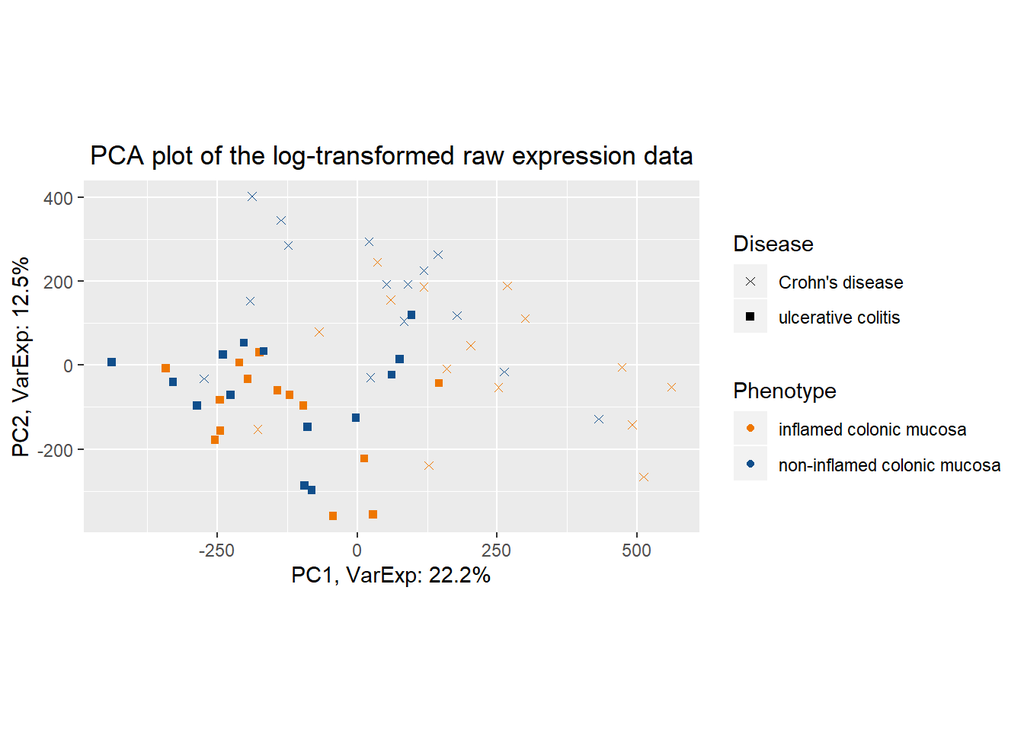

```r
exp_raw <- log2(Biobase::exprs(raw_data))
PCA_raw <- prcomp(t(exp_raw), scale. = FALSE)

percentVar <- round(100*PCA_raw$sdev^2/sum(PCA_raw$sdev^2),1)
sd_ratio <- sqrt(percentVar[2] / percentVar[1])

dataGG <- data.frame(PC1 = PCA_raw$x[,1], PC2 = PCA_raw$x[,2],
                    Disease = pData(raw_data)$Factor.Value.disease.,
                    Phenotype = pData(raw_data)$Factor.Value.phenotype.,
                    Individual = pData(raw_data)$Characteristics.individual.)

ggplot(dataGG, aes(PC1, PC2)) +
      geom_point(aes(shape = Disease, colour = Phenotype)) +
  ggtitle("PCA plot of the log-transformed raw expression data") +
  xlab(paste0("PC1, VarExp: ", percentVar[1], "%")) +
  ylab(paste0("PC2, VarExp: ", percentVar[2], "%")) +
  theme(plot.title = element_text(hjust = 0.5))+
  coord_fixed(ratio = sd_ratio) +
  scale_shape_manual(values = c(4,15)) +
  scale_color_manual(values = c("darkorange2", "dodgerblue4"))
```

We also represent the probe intensities via a boxplot graph with one box per individual microarray. (Figure 3).

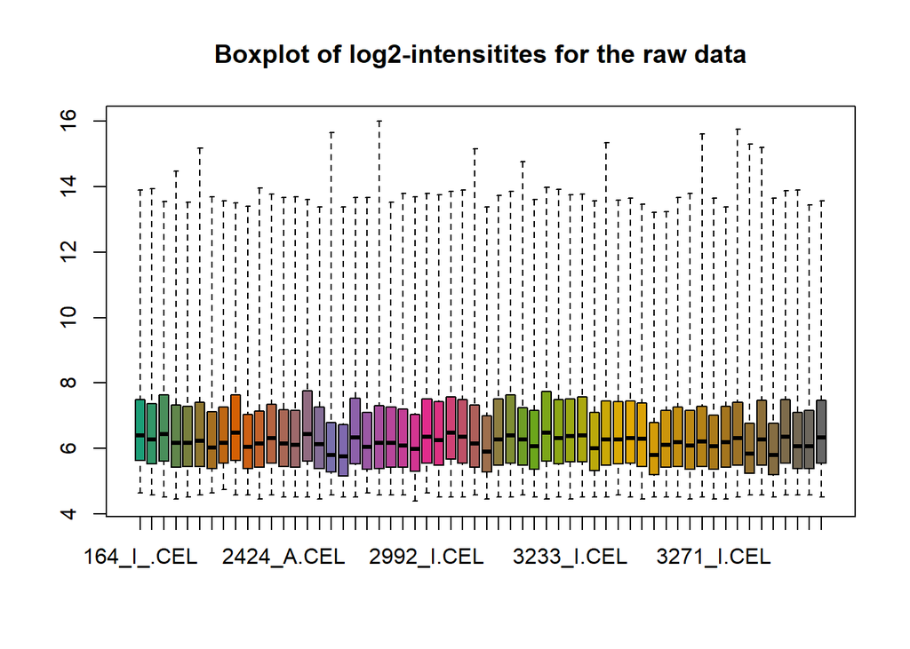

```r
oligo::boxplot(raw_data, target = "core",
               main = "Boxplot of log2-intensitites for the raw data")
```